# KNN and LDA Problem Set

Seungjun (Josh) Kim

## ISLR 4.7 Q10

#### a. Produce some numerical and graphical summaries of the “Weekly” data. Do there appear to be any patterns ?

```r
library(ISLR)
library(tidyverse)
library(ggplot2)
library(ggthemes)
```

```r
summary(Weekly)
```

```
##       Year           Lag1               Lag2               Lag3
##  Min.   :1990   Min.   :-18.1950   Min.   :-18.1950   Min.   :-18.1950
##  1st Qu.:1995   1st Qu.: -1.1540   1st Qu.: -1.1540   1st Qu.: -1.1580
##  Median :2000   Median :  0.2410   Median :  0.2410   Median :  0.2410
##  Mean   :2000   Mean   :  0.1506   Mean   :  0.1511   Mean   :  0.1472
##  3rd Qu.:2005   3rd Qu.:  1.4050   3rd Qu.:  1.4090   3rd Qu.:  1.4090
##  Max.   :2010   Max.   : 12.0260   Max.   : 12.0260   Max.   : 12.0260
##       Lag4               Lag5              Volume
##  Min.   :-18.1950   Min.   :-18.1950   Min.   :0.08747
##  1st Qu.: -1.1580   1st Qu.: -1.1660   1st Qu.:0.33202
##  Median :  0.2380   Median :  0.2340   Median :1.00268
##  Mean   :  0.1458   Mean   :  0.1399   Mean   :1.57462
##  3rd Qu.:  1.4090   3rd Qu.:  1.4050   3rd Qu.:2.05373
##  Max.   : 12.0260   Max.   : 12.0260   Max.   :9.32821
##      Today          Direction
##  Min.   :-18.1950   Down:484
##  1st Qu.: -1.1540   Up  :605
##  Median :  0.2410
##  Mean   :  0.1499
##  3rd Qu.:  1.4050
##  Max.   : 12.0260
```

```r
head(Weekly)
```

|  | Year | Lag1 | Lag2 | Lag3 | Lag4 | Lag5 | Volume | Today | Direction |
| --- | --- | --- | --- | --- | --- | --- | --- | --- | --- |
| 1 | 1990 | 0.816 | 1.572 | -3.936 | -0.229 | -3.484 | 0.1549760 | -0.270 | Down |
| 2 | 1990 | -0.270 | 0.816 | 1.572 | -3.936 | -0.229 | 0.1485740 | -2.576 | Down |
| 3 | 1990 | -2.576 | -0.270 | 0.816 | 1.572 | -3.936 | 0.1598375 | 3.514 | Up |
| 4 | 1990 | 3.514 | -2.576 | -0.270 | 0.816 | 1.572 | 0.1616300 | 0.712 | Up |
| 5 | 1990 | 0.712 | 3.514 | -2.576 | -0.270 | 0.816 | 0.1537280 | 1.178 | Up |
| 6 | 1990 | 1.178 | 0.712 | 3.514 | -2.576 | -0.270 | 0.1544440 | -1.372 | Down |

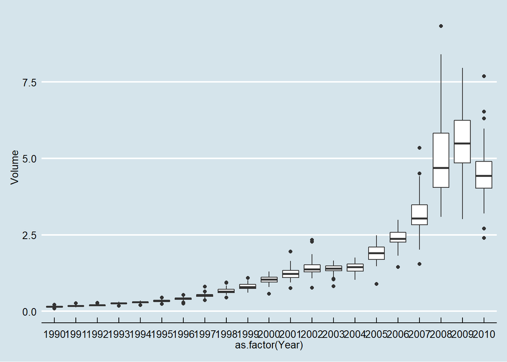

```r
ggplot(data=Weekly, aes(x=as.factor(Year),y=Volume)) + geom_boxplot() + theme_economist()
```

The overall volume of stock transactions is increasing over time. The variability of the volume has been increasing epsecially from 2005 to 2010 as we can see from the boxes that stretch wider across the y axis in the more recent years.

```r
# Correlation
cor(Weekly[, -9])
```

```
##               Year         Lag1        Lag2        Lag3         Lag4
## Year    1.00000000 -0.032289274 -0.03339001 -0.03000649 -0.031127923
## Lag1   -0.03228927  1.000000000 -0.07485305  0.05863568 -0.071273876
## Lag2   -0.03339001 -0.074853051  1.00000000 -0.07572091  0.058381535
## Lag3   -0.03000649  0.058635682 -0.07572091  1.00000000 -0.075395865
## Lag4   -0.03112792 -0.071273876  0.05838153 -0.07539587  1.000000000
## Lag5   -0.03051910 -0.008183096 -0.07249948  0.06065717 -0.075675027
## Volume  0.84194162 -0.064951313 -0.08551314 -0.06928771 -0.061074617
## Today  -0.03245989 -0.075031842  0.05916672 -0.07124364 -0.007825873
##                Lag5      Volume        Today
## Year   -0.030519101  0.84194162 -0.032459894
## Lag1   -0.008183096 -0.06495131 -0.075031842
## Lag2   -0.072499482 -0.08551314  0.059166717
## Lag3    0.060657175 -0.06928771 -0.071243639
## Lag4   -0.075675027 -0.06107462 -0.007825873
## Lag5    1.000000000 -0.05851741  0.011012698
## Volume -0.058517414  1.00000000 -0.033077783
## Today   0.011012698 -0.03307778  1.000000000
```

We also observe from the the correlation marix above that lag variables and returns barely have any correlation.

#### b. Use the full data set to perform a logistic regression with “Direction” as the response and the five lag variables plus “Volume” as predictors. Use the summary function to print the results. Do any of the predictors appear to be statistically significant ? If so, which ones ?

```r
fit.glm <- glm(Direction ~ Lag1 + Lag2 + Lag3 + Lag4 + Lag5 + Volume, data = Weekly, family = binomial)
summary(fit.glm)
```

```
##
## Call:
## glm(formula = Direction ~ Lag1 + Lag2 + Lag3 + Lag4 + Lag5 +
##     Volume, family = binomial, data = Weekly)
##
## Deviance Residuals:
##     Min       1Q   Median       3Q      Max
## -1.6949  -1.2565   0.9913   1.0849   1.4579
##
## Coefficients:
##             Estimate Std. Error z value Pr(>|z|)
## (Intercept)  0.26686    0.08593   3.106   0.0019 **
## Lag1        -0.04127    0.02641  -1.563   0.1181
## Lag2         0.05844    0.02686   2.175   0.0296 *
## Lag3        -0.01606    0.02666  -0.602   0.5469
## Lag4        -0.02779    0.02646  -1.050   0.2937
## Lag5        -0.01447    0.02638  -0.549   0.5833
## Volume      -0.02274    0.03690  -0.616   0.5377
## ---
## Signif. codes:  0 '***' 0.001 '**' 0.01 '*' 0.05 '.' 0.1 ' ' 1
##
## (Dispersion parameter for binomial family taken to be 1)
##
##     Null deviance: 1496.2  on 1088  degrees of freedom
## Residual deviance: 1486.4  on 1082  degrees of freedom
## AIC: 1500.4
##
## Number of Fisher Scoring iterations: 4
```

Only the Lag2 variable is statistically significant as we can see from the small p-value less than the typical significance threshold of 5%.

#### c. Compute the confusion matrix and overall fraction of correct predictions. Explain what the confusion matrix is telling you about the types of mistakes made by logistic regression.

```r
probabilities <- predict(fit.glm, type = "response")
```

```r
pred.glm <- rep("Down", length(probabilities))
```

```r
# Threshold prob value for determining up or down --> 0.5
pred.glm[probabilities > 0.5] <- "Up"
```

```r
#  Confusion matrix predicted v.s. actual
table(pred.glm, Weekly$Direction)
```

```
##
## pred.glm Down  Up
##     Down   54  48
##     Up    430 557
```

The accuracy of the model can be calculated as the percentage of correct predictions out of the entire training data which is (54+557)/(54+48+430+557) = 56.1%. This means the training error rate is 1-56.1% = 43.9%. Precision, the proportion of correctly predicted positives out of all the observations predicted to be positive, is (557 / 430+557)=56.4%. We can also calculate recall could also say that for weeks when the stock price went up, the model predicted that rise correctly with 92.1% probability (557/(48+557)).

#### d. Now fit the logistic regression model using a training data period from 1990 to 2008, with “Lag2” as the only predictor. Compute the confusion matrix and the overall fraction of correct predictions for the held out data (that is, the data from 2009 to 2010).

```r
train <- (Weekly$Year < 2009) #Period 1990 to 2008

Weekly.hod <- Weekly[!train, ] # held out data (hod)
fit.glm2 <- glm(Direction ~ Lag2, data = Weekly, family = binomial, subset = train)
summary(fit.glm2)
```

```
##
## Call:
## glm(formula = Direction ~ Lag2, family = binomial, data = Weekly,
##     subset = train)
##
## Deviance Residuals:
##    Min      1Q  Median      3Q     Max
## -1.536  -1.264   1.021   1.091   1.368
##
## Coefficients:
##             Estimate Std. Error z value Pr(>|z|)
## (Intercept)  0.20326    0.06428   3.162  0.00157 **
## Lag2         0.05810    0.02870   2.024  0.04298 *
## ---
## Signif. codes:  0 '***' 0.001 '**' 0.01 '*' 0.05 '.' 0.1 ' ' 1
##
## (Dispersion parameter for binomial family taken to be 1)
##
##     Null deviance: 1354.7  on 984  degrees of freedom
## Residual deviance: 1350.5  on 983  degrees of freedom
## AIC: 1354.5
##
## Number of Fisher Scoring iterations: 4
```

```r
probabilities2 <- predict(fit.glm2, Weekly.hod, type = "response")
pred.glm2 <- rep("Down", length(probabilities2))
pred.glm2[probabilities2 > 0.5] <- "Up"

# confusion matrix
table(pred.glm2, Weekly.hod$Direction)
```

```
##
## pred.glm2 Down Up
##      Down    9  5
##      Up     34 56
```

Overall fraction of correct predictions for the held out data is (9+56)/104 = 0.625 = 62.5%

#### e. Repeat (d) using LDA.

```r
library(MASS)
fit.lda <- lda(Direction ~ Lag2, data = Weekly, subset = train)
fit.lda
```

```
## Call:
## lda(Direction ~ Lag2, data = Weekly, subset = train)
##
## Prior probabilities of groups:
##      Down        Up
## 0.4477157 0.5522843
##
## Group means:
##             Lag2
## Down -0.03568254
## Up    0.26036581
##
## Coefficients of linear discriminants:
##            LD1
## Lag2 0.4414162
```

```r
pred.lda <- predict(fit.lda, Weekly.hod)
table(pred.lda$class, Weekly.hod$Direction)
```

```
##
##        Down Up
##   Down    9  5
##   Up     34 56
```

We got the same confusion matrix as (d), so the accuracy is the same (62.5%)

#### f. Repeat (d) using QDA.

```r
fit.qda <- qda(Direction ~ Lag2, data = Weekly, subset = train)
fit.qda
```

```
## Call:
## qda(Direction ~ Lag2, data = Weekly, subset = train)
##
## Prior probabilities of groups:
##      Down        Up
## 0.4477157 0.5522843
##
## Group means:
##             Lag2
## Down -0.03568254
## Up    0.26036581
```

```r
pred.qda <- predict(fit.qda, Weekly.hod)
table(pred.qda$class, Weekly.hod$Direction)
```

```
##
##        Down Up
##   Down    0  0
##   Up     43 61
```

Accuracy score, the percentage of correct predictions on the test data is 61 / (43+61) = 58.65%.

#### g. Repeat (d) using KNN with K=1.

```r
library(class)

train.Direction = Weekly$Direction[train]

train_X <- as.matrix(Weekly$Lag2[train])
test_X <- as.matrix(Weekly$Lag2[!train])

set.seed(42) #josh's fav number as seed

pred.knn <- knn(train_X, test_X, train.Direction, k = 1)
table(pred.knn, Weekly.hod$Direction)
```

```
##
## pred.knn Down Up
##     Down   21 30
##     Up     22 31
```

```r
# Accuracy for k=1 knn
mean(pred.knn == Weekly.hod$Direction)
```

```
## [1] 0.5
```

Accuracy score is 50% for k=1 knn model.